# Assessment of the Happiness Index of UP Diliman Undergraduate Students using Multivariate Analysis

Clarisse Rodriguez, Lara Elio, Iana Garcia

```r
library(psych)
library(MVN)
library("GPArotation")
library(MVN)
library(devtools)
library(factoextra)
library(cluster)
library(dendextend)
library(psych)
library(biotools)
library(tidyverse)
library(cluster)
library(factoextra)
library(knitr)
```

```r
hpind<-read.csv('hpindex2.csv',fill=TRUE)
```

```r
new_hp2<-hpind[,7:38] #removes columns on demographics

names(new_hp2)<- c('happiness_level', 'vitamin_intake',  'enough_sleep', 'physical_activities', 'physical_appearance', 'sleep_quality', 'degree_prog_satisfaction', 'class_anticipation', 'class_participation', 'degree_program_performance', 'learnings', 'university_satisfaction', 'leisure_time', 'procrastination', 'hobbies', 'multimedia', 'pos_effect_social_med', 'positive_outlook', 'regrets', 'sense_of_meaning_purpose', 'optimism_of_future', 'life_control', 'rewarding_view_of_life', 'happiness_choice', 'family_relationship', 'peer_relationship', 'company_of_animals', 'love_and_affection', 'social_interaction', 'extra_curricular', 'campus_safety', 'safety_going_home')
```

```r
kable(head(new_hp2))
```

| happiness_level | vitamin_intake | enough_sleep | physical_activities | physical_appearance | sleep_quality | degree_prog_satisfaction | class_anticipation | class_participation | degree_program_performance | learnings | university_satisfaction | leisure_time | procrastination | hobbies | multimedia | pos_effect_social_med | positive_outlook | regrets | sense_of_meaning_purpose | optimism_of_future | life_control | rewarding_view_of_life | happiness_choice | family_relationship | peer_relationship | company_of_animals | love_and_affection | social_interaction | extra_curricular | … |
| --- | --- | --- | --- | --- | --- | --- | --- | --- | --- | --- | --- | --- | --- | --- | --- | --- | --- | --- | --- | --- | --- | --- | --- | --- | --- | --- | --- | --- | --- | --- |
| 3 | 1 | 2 | 3 | 3 | 2 | 4 | 3 | 3 | 3 | 3 | 4 | 2 | 3 | 3 | 3 | 3 | 3 | 2 | 3 | 3 | 3 | 3 | 4 | 3 | 4 | 4 | 4 | 3 | 3 | … |
| 3 | 1 | 3 | 2 | 3 | 3 | 3 | 2 | 2 | 3 | 3 | 4 | 2 | 2 | 2 | 4 | 3 | 2 | 2 | 2 | 2 | 2 | 3 | 3 | 4 | 3 | 3 | 3 | 2 | 2 | … |
| 3 | 1 | 4 | 3 | 2 | 2 | 4 | 2 | 2 | 3 | 3 | 3 | 2 | 1 | 3 | 3 | 2 | 3 | 1 | 3 | 3 | 3 | 3 | 3 | 3 | 3 | 3 | 3 | 2 | 1 | … |
| 3 | 1 | 3 | 1 | 3 | 3 | 2 | 2 | 2 | 3 | 2 | 3 | 2 | 2 | 3 | 3 | 3 | 3 | 2 | 3 | 3 | 2 | 3 | 3 | 3 | 3 | 4 | 4 | 2 | 1 | … |
| 1 | 1 | 2 | 1 | 2 | 2 | 1 | 1 | 2 | 2 | 2 | 2 | 1 | 1 | 4 | 4 | 3 | 2 | 1 | 2 | 2 | 2 | 2 | 3 | 3 | 3 | 3 | 3 | 2 | 2 | … |
| 3 | 3 | 1 | 2 | 3 | 1 | 3 | 2 | 3 | 2 | 2 | 3 | 2 | 2 | 2 | 4 | 3 | 3 | 2 | 4 | 4 | 2 | 4 | 3 | 4 | 3 | 1 | 2 | 3 | 4 | … |

```r
kable(describe(new_hp2))
```

|  | vars | n | mean | sd | median | trimmed | mad | min | max | range | skew | kurtosis | se |
| --- | --- | --- | --- | --- | --- | --- | --- | --- | --- | --- | --- | --- | --- |
| happiness_level | 1 | 159 | 2.805031 | 0.6606287 | 3 | 2.806202 | 0.0000 | 1 | 4 | 3 | -0.5560081 | 0.6706330 | 0.0523913 |
| vitamin_intake | 2 | 159 | 2.012579 | 0.9611927 | 2 | 1.922481 | 1.4826 | 1 | 4 | 3 | 0.4850720 | -0.8896365 | 0.0762275 |
| enough_sleep | 3 | 159 | 2.163522 | 0.8181038 | 2 | 2.139535 | 1.4826 | 1 | 4 | 3 | 0.2461292 | -0.5443294 | 0.0648799 |
| physical_activities | 4 | 159 | 2.245283 | 0.7353375 | 2 | 2.271318 | 1.4826 | 1 | 4 | 3 | -0.0350027 | -0.5530330 | 0.0583161 |
| physical_appearance | 5 | 159 | 2.584906 | 0.6871505 | 3 | 2.620155 | 0.0000 | 1 | 4 | 3 | -0.4211245 | -0.0639351 | 0.0544946 |
| sleep_quality | 6 | 159 | 2.157233 | 0.7508189 | 2 | 2.131783 | 0.0000 | 1 | 4 | 3 | 0.4512488 | 0.0990615 | 0.0595438 |
| degree_prog_satisfaction | 7 | 159 | 2.943396 | 0.7895302 | 3 | 2.992248 | 0.0000 | 1 | 4 | 3 | -0.5143077 | -0.0219762 | 0.0626138 |
| class_anticipation | 8 | 159 | 2.364780 | 0.7413756 | 2 | 2.387597 | 1.4826 | 1 | 4 | 3 | 0.0501120 | -0.3536916 | 0.0587949 |
| class_participation | 9 | 159 | 2.540881 | 0.6819753 | 3 | 2.558139 | 1.4826 | 1 | 4 | 3 | -0.2061818 | -0.2116378 | 0.0540842 |
| degree_program_performance | 10 | 159 | 2.477987 | 0.7699784 | 3 | 2.503876 | 1.4826 | 1 | 4 | 3 | -0.1334665 | -0.4267370 | 0.0610633 |
| learnings | 11 | 159 | 3.150943 | 0.6674027 | 3 | 3.201550 | 0.0000 | 1 | 4 | 3 | -0.4319223 | 0.1896944 | 0.0529285 |
| university_satisfaction | 12 | 159 | 3.081761 | 0.6747578 | 3 | 3.131783 | 0.0000 | 1 | 4 | 3 | -0.5881969 | 0.8684358 | 0.0535118 |
| leisure_time | 13 | 159 | 2.119497 | 0.8063418 | 2 | 2.100775 | 1.4826 | 1 | 4 | 3 | 0.2147461 | -0.6254300 | 0.0639471 |
| procrastination | 14 | 159 | 1.823899 | 0.8384328 | 2 | 1.728682 | 1.4826 | 1 | 4 | 3 | 0.7848008 | -0.0602042 | 0.0664920 |
| hobbies | 15 | 159 | 3.056604 | 0.6773485 | 3 | 3.093023 | 0.0000 | 1 | 4 | 3 | -0.4318484 | 0.3593880 | 0.0537172 |
| multimedia | 16 | 159 | 3.433962 | 0.5684567 | 3 | 3.457364 | 0.0000 | 1 | 4 | 3 | -0.5637049 | 0.5083698 | 0.0450816 |
| pos_effect_social_med | 17 | 159 | 2.830189 | 0.7134117 | 3 | 2.844961 | 0.0000 | 1 | 4 | 3 | -0.4720982 | 0.3127539 | 0.0565772 |
| positive_outlook | 18 | 159 | 2.735849 | 0.7750282 | 3 | 2.728682 | 1.4826 | 1 | 4 | 3 | -0.0791834 | -0.5020721 | 0.0614637 |
| regrets | 19 | 159 | 1.918239 | 0.7288673 | 2 | 1.868217 | 0.0000 | 1 | 4 | 3 | 0.5144907 | 0.1195500 | 0.0578029 |
| sense_of_meaning_purpose | 20 | 159 | 2.597484 | 0.7885213 | 3 | 2.612403 | 1.4826 | 1 | 4 | 3 | -0.2437671 | -0.3688615 | 0.0625338 |
| optimism_of_future | 21 | 159 | 2.723270 | 0.8412765 | 3 | 2.751938 | 1.4826 | 1 | 4 | 3 | -0.2091003 | -0.5669791 | 0.0667176 |
| life_control | 22 | 159 | 2.484277 | 0.7618710 | 3 | 2.511628 | 1.4826 | 1 | 4 | 3 | -0.1180194 | -0.4000533 | 0.0604203 |
| rewarding_view_of_life | 23 | 159 | 2.748428 | 0.7792284 | 3 | 2.759690 | 0.0000 | 1 | 4 | 3 | -0.2533972 | -0.3090070 | 0.0617968 |
| happiness_choice | 24 | 159 | 2.893082 | 0.8236319 | 3 | 2.945736 | 0.0000 | 1 | 4 | 3 | -0.4775728 | -0.2190164 | 0.0653183 |
| family_relationship | 25 | 159 | 3.088050 | 0.8142998 | 3 | 3.170543 | 1.4826 | 1 | 4 | 3 | -0.7196450 | 0.1308747 | 0.0645782 |
| peer_relationship | 26 | 159 | 3.194969 | 0.5566399 | 3 | 3.209302 | 0.0000 | 1 | 4 | 3 | -0.1755083 | 0.8885315 | 0.0441444 |
| company_of_animals | 27 | 159 | 3.119497 | 0.9096166 | 3 | 3.240310 | 1.4826 | 1 | 4 | 3 | -0.8367982 | -0.1186993 | 0.0721373 |
| love_and_affection | 28 | 159 | 2.962264 | 0.7537820 | 3 | 2.984496 | 0.0000 | 1 | 4 | 3 | -0.2911746 | -0.3848245 | 0.0597788 |
| social_interaction | 29 | 159 | 2.704403 | 0.7339287 | 3 | 2.689923 | 0.0000 | 1 | 4 | 3 | -0.1498792 | -0.2681676 | 0.0582043 |
| extra_curricular | 30 | 159 | 2.201258 | 0.7695130 | 2 | 2.186046 | 0.0000 | 1 | 4 | 3 | 0.3066198 | -0.2177226 | 0.0610264 |
| campus_safety | 31 | 159 | 2.515723 | 0.6642341 | 3 | 2.573643 | 0.0000 | 1 | 4 | 3 | -0.5078377 | -0.2110440 | 0.0526772 |
| safety_going_home | 32 | 159 | 2.433962 | 0.7674411 | 2 | 2.465116 | 1.4826 | 1 | 4 | 3 | -0.1550558 | -0.4697048 | 0.0608620 |

## A. Factor Analysis

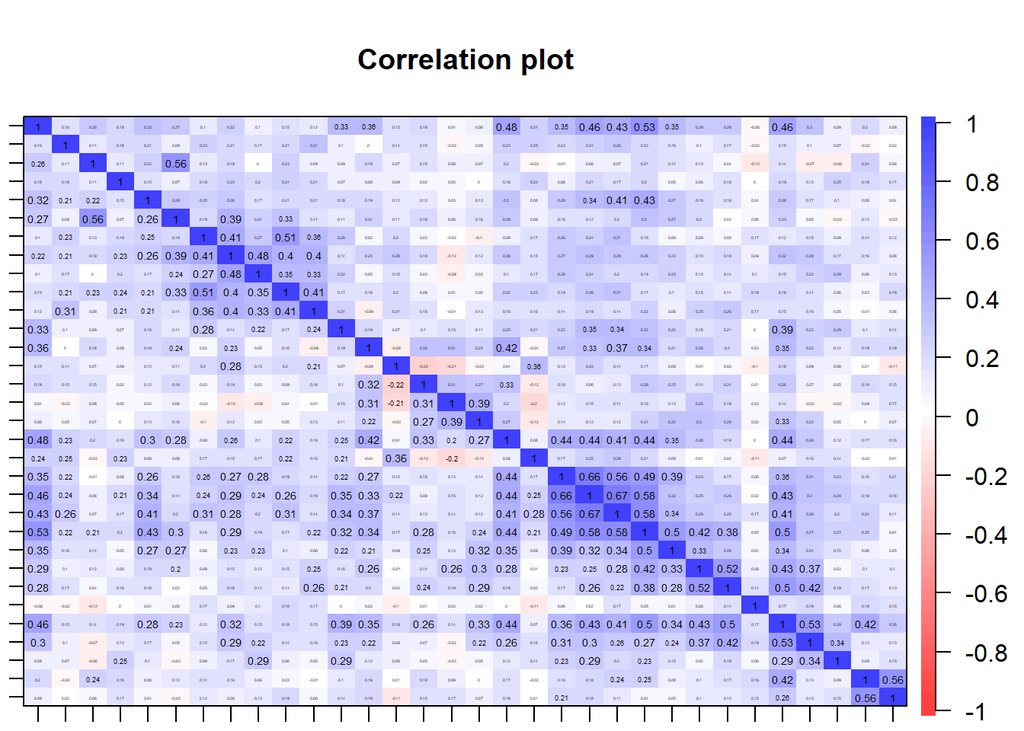

```r
cor<-cor(new_hp2)
#lowerCor(new_hp2)
corPlot(new_hp2,numbers=T, MAR=0.5, labels = 1:32)
```

The correlation matrix above shows that the variables are not that correlated to each other. To evaluate the ‘factorability’ of the data, the Bartlett’s test of Sphericity and Kaiser-Meyer-Olkin measure of sampling adequacy were performed.

### A.1. Factorability Tests

Bartlett’s test of Sphericity tests the null hypothesis that the correlation matrix is an identity matrix, which means that the variables are unrelated and not ideal for factor analysis.

```r
cortest.bartlett(new_hp2)
```

```
## R was not square, finding R from data
```

```
## $chisq
## [1] 1810.035
##
## $p.value
## [1] 1.167642e-148
##
## $df
## [1] 496
```

Since the p-value is less than 0.05, we reject the null hypothesis that the variables are unrelated.

```r
KMO(new_hp2)
```

```
## Kaiser-Meyer-Olkin factor adequacy
## Call: KMO(r = new_hp2)
## Overall MSA =  0.8
## MSA for each item =
##            happiness_level             vitamin_intake
##                       0.90                       0.82
##               enough_sleep        physical_activities
##                       0.64                       0.77
##        physical_appearance              sleep_quality
##                       0.89                       0.75
##   degree_prog_satisfaction         class_anticipation
##                       0.75                       0.84
##        class_participation degree_program_performance
##                       0.79                       0.77
##                  learnings    university_satisfaction
##                       0.70                       0.72
##               leisure_time            procrastination
##                       0.85                       0.68
##                    hobbies                 multimedia
##                       0.73                       0.70
##      pos_effect_social_med           positive_outlook
##                       0.77                       0.92
##                    regrets   sense_of_meaning_purpose
##                       0.73                       0.86
##         optimism_of_future               life_control
##                       0.89                       0.87
##     rewarding_view_of_life           happiness_choice
##                       0.90                       0.88
##        family_relationship          peer_relationship
##                       0.78                       0.86
##         company_of_animals         love_and_affection
##                       0.51                       0.85
##         social_interaction           extra_curricular
##                       0.85                       0.76
##              campus_safety          safety_going_home
##                       0.58                       0.57
```

The overall Measure of Sampling Adequacy (MSA) for the set of variables is 0.8, indicating that correlations between pairs of variables can be explained by the other variables. Moreover, the individual MSAs are all above 0.5 hence, factor analysis is appropriate for the data.

### A.2. Factor Analysis Proper

To aid in the selection of the appropriate method to use for factor extraction, the variables were tested for multivariate normality.

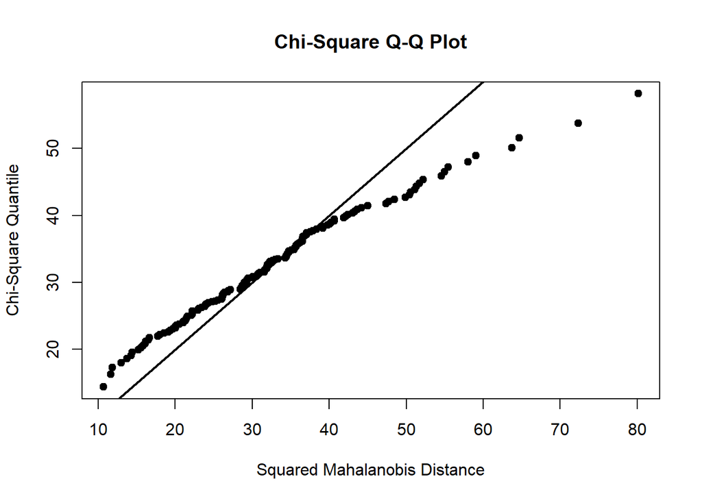

```
## $multivariateNormality
##            Test       HZ p value MVN
## 1 Henze-Zirkler 1.000335       0  NO
##
## $univariateNormality
##                Test                   Variable Statistic   p value Normality
## 1  Anderson-Darling      happiness_level         18.0345  <0.001      NO
## 2  Anderson-Darling       vitamin_intake          9.9494  <0.001      NO
## 3  Anderson-Darling        enough_sleep           9.8890  <0.001      NO
## 4  Anderson-Darling    physical_activities       12.1844  <0.001      NO
## 5  Anderson-Darling    physical_appearance       15.6425  <0.001      NO
## 6  Anderson-Darling       sleep_quality          13.1187  <0.001      NO
## 7  Anderson-Darling  degree_prog_satisfaction    11.6865  <0.001      NO
## 8  Anderson-Darling     class_anticipation       12.0248  <0.001      NO
## 9  Anderson-Darling    class_participation       14.7726  <0.001      NO
## 10 Anderson-Darling degree_program_performance   11.3196  <0.001      NO
## 11 Anderson-Darling         learnings            15.4846  <0.001      NO
## 12 Anderson-Darling  university_satisfaction     16.4595  <0.001      NO
## 13 Anderson-Darling        leisure_time          10.1749  <0.001      NO
## 14 Anderson-Darling      procrastination         12.0124  <0.001      NO
## 15 Anderson-Darling          hobbies             15.4015  <0.001      NO
## 16 Anderson-Darling         multimedia           22.0239  <0.001      NO
## 17 Anderson-Darling   pos_effect_social_med      14.8656  <0.001      NO
## 18 Anderson-Darling      positive_outlook        10.8890  <0.001      NO
## 19 Anderson-Darling          regrets             13.2174  <0.001      NO
## 20 Anderson-Darling  sense_of_meaning_purpose    11.1532  <0.001      NO
## 21 Anderson-Darling     optimism_of_future        9.3379  <0.001      NO
## 22 Anderson-Darling        life_control          11.5135  <0.001      NO
## 23 Anderson-Darling   rewarding_view_of_life     11.1536  <0.001      NO
## 24 Anderson-Darling      happiness_choice        10.6861  <0.001      NO
## 25 Anderson-Darling    family_relationship       11.7514  <0.001      NO
## 26 Anderson-Darling     peer_relationship        22.9795  <0.001      NO
## 27 Anderson-Darling     company_of_animals       11.6386  <0.001      NO
## 28 Anderson-Darling     love_and_affection       11.7200  <0.001      NO
## 29 Anderson-Darling     social_interaction       12.4321  <0.001      NO
## 30 Anderson-Darling      extra_curricular        11.6117  <0.001      NO
## 31 Anderson-Darling       campus_safety          16.9183  <0.001      NO
## 32 Anderson-Darling     safety_going_home        11.5048  <0.001      NO
##
## $Descriptives
```

[output cut: 51 more lines]

```
## positive_outlook           -0.07918336 -0.50207208
## regrets                     0.51449074  0.11954999
## sense_of_meaning_purpose   -0.24376706 -0.36886146
## optimism_of_future         -0.20910034 -0.56697913
## life_control               -0.11801935 -0.40005335
## rewarding_view_of_life     -0.25339725 -0.30900700
## happiness_choice           -0.47757283 -0.21901640
## family_relationship        -0.71964504  0.13087472
## peer_relationship          -0.17550834  0.88853149
## company_of_animals         -0.83679823 -0.11869927
## love_and_affection         -0.29117462 -0.38482445
## social_interaction         -0.14987918 -0.26816762
## extra_curricular            0.30661978 -0.21772263
## campus_safety              -0.50783774 -0.21104397
## safety_going_home          -0.15505581 -0.46970478
```

```r
mvn(new_hp2,subset=NULL,multivariatePlot = "qq")
```

```r
mvn_hz = mvn(new_hp2, mvnTest = "hz")
mvn_royston = mvn(new_hp2, mvnTest = "royston")

print(mvn_hz$multivariateNormality)
```

```
##            Test       HZ p value MVN
## 1 Henze-Zirkler 1.000335       0  NO
```

```r
print(mvn_royston$multivariateNormality)
```

```
##      Test        H       p value MVN
## 1 Royston 1634.643 1.482197e-323  NO
```

The above tests rejected the assumption of multivariate normality. Because of this, the Maximum Likelihood Solution is not applicable. Thus, the Principal Components Solution will be used to estimate the factor scores.

#### A.2.a. Principal Components Solution

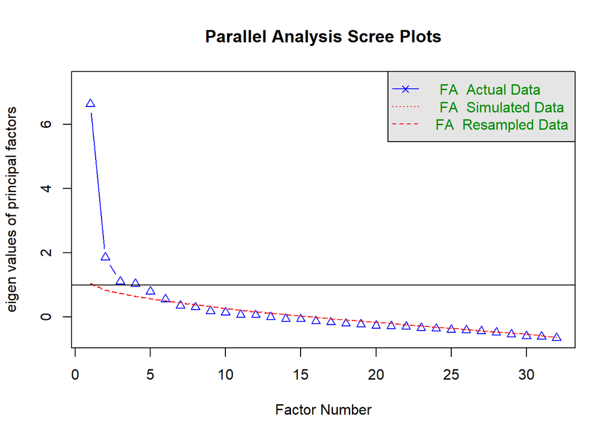

```
## Parallel analysis suggests that the number of factors =  5  and the number of components =  NA
```

```r
names(new_hp2) <- 1:32

#standardize the data
scaled.hp1<-scale(new_hp2)

# obtain a parallel analysis on the standardized data to determine the number of factors
fa.parallel(scaled.hp1, fa='fa')
```

Based on the parallel analysis scree plots, it is possible to extract 5-6 factors.

PC solutions with no rotations would be considered first.

```r
# Extract factors from the standardized data.
pcsolution1<-principal(scaled.hp1,nfactors=6,rotate="none")
pcsolution1
```

```
## Principal Components Analysis
## Call: principal(r = scaled.hp1, nfactors = 6, rotate = "none")
## Standardized loadings (pattern matrix) based upon correlation matrix
##     PC1   PC2   PC3   PC4   PC5   PC6   h2   u2 com
## 1  0.62 -0.08 -0.01 -0.35  0.16  0.21 0.59 0.41 2.0
## 2  0.36  0.28  0.07 -0.09 -0.16 -0.20 0.28 0.72 3.3
## 3  0.28 -0.03  0.67 -0.11  0.22  0.33 0.70 0.30 2.2
## 4  0.33  0.23 -0.04  0.18  0.16  0.13 0.24 0.76 3.4
## 5  0.51  0.09  0.16 -0.18  0.01 -0.06 0.33 0.67 1.6
## 6  0.42  0.07  0.64 -0.12  0.03  0.20 0.64 0.36 2.1
## 7  0.40  0.49  0.17  0.28  0.08 -0.25 0.58 0.42 3.5
## 8  0.55  0.37  0.24  0.18 -0.10  0.12 0.55 0.45 2.6
## 9  0.41  0.40 -0.01  0.25 -0.13 -0.05 0.41 0.59 2.9
## 10 0.46  0.41  0.32  0.28 -0.01 -0.19 0.60 0.40 3.9
## 11 0.40  0.38  0.18  0.30 -0.40 -0.11 0.60 0.40 4.4
## 12 0.48  0.04 -0.17 -0.01  0.04 -0.07 0.27 0.73 1.3
## 13 0.49 -0.40  0.11 -0.06  0.22 -0.06 0.46 0.54 2.5
## 14 0.23  0.51 -0.06 -0.26 -0.06  0.30 0.47 0.53 2.7
## 15 0.35 -0.40  0.29  0.13 -0.05 -0.17 0.42 0.58 3.5
## 16 0.22 -0.56  0.15  0.13 -0.04 -0.39 0.55 0.45 2.4
## 17 0.33 -0.44  0.11  0.05 -0.43 -0.04 0.50 0.50 3.0
## 18 0.63 -0.22  0.10 -0.19  0.08 -0.10 0.51 0.49 1.6
## 19 0.27  0.50 -0.23 -0.28  0.08  0.09 0.47 0.53 2.9
## 20 0.63  0.01 -0.23 -0.16  0.14 -0.34 0.62 0.38 2.1
## 21 0.71  0.06 -0.26 -0.23  0.18 -0.24 0.72 0.28 1.9
## 22 0.70  0.05 -0.16 -0.18  0.19 -0.30 0.68 0.32 1.8
## 23 0.75 -0.11 -0.04 -0.27 -0.02  0.02 0.65 0.35 1.3
## 24 0.55 -0.18  0.01 -0.23 -0.20  0.02 0.42 0.58 1.9
## 25 0.51 -0.29  0.00  0.07 -0.38  0.15 0.52 0.48 2.8
## 26 0.51 -0.24 -0.20  0.22 -0.39  0.24 0.62 0.38 3.8
## 27 0.15  0.00 -0.09  0.53 -0.04 -0.12 0.33 0.67 1.3
## 28 0.71 -0.23 -0.18  0.12 -0.01  0.33 0.72 0.28 1.9
## 29 0.51 -0.04 -0.40  0.18 -0.24  0.29 0.59 0.41 3.3
## 30 0.34  0.10 -0.46  0.13  0.06  0.09 0.36 0.64 2.3
## 31 0.35 -0.19  0.00  0.38  0.58  0.30 0.73 0.27 3.4
## 32 0.28 -0.16 -0.10  0.53  0.49  0.01 0.64 0.36 2.8
##
##                        PC1  PC2  PC3  PC4  PC5  PC6
## SS loadings           7.33 2.71 1.93 1.85 1.64 1.33
## Proportion Var        0.23 0.08 0.06 0.06 0.05 0.04
## Cumulative Var        0.23 0.31 0.37 0.43 0.48 0.52
## Proportion Explained  0.44 0.16 0.11 0.11 0.10 0.08
## Cumulative Proportion 0.44 0.60 0.71 0.82 0.92 1.00
##
## Mean item complexity =  2.6
## Test of the hypothesis that 6 components are sufficient.
##
## The root mean square of the residuals (RMSR) is  0.06
##  with the empirical chi square  516.18  with prob <  1.6e-11
##
## Fit based upon off diagonal values = 0.94
```

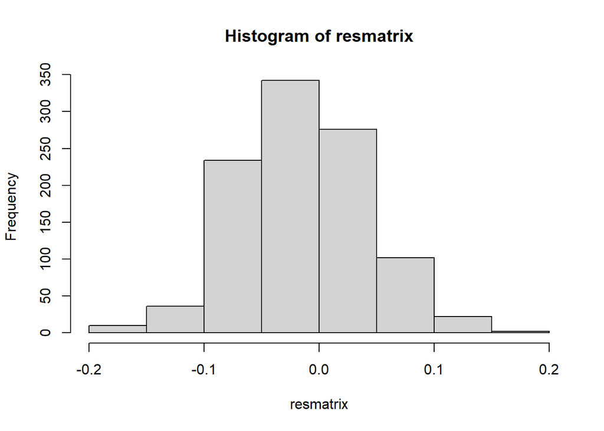

```r
# Getting the residual matrix: The residual matrix is a measure of how good our model is. Ideally, the residual matrix is close to null.


L<-pcsolution1$loadings
llT<-L%*%t(L)
uniqueness<-cor-llT

m<-matrix(0,32,32)
diag(m)<-diag(uniqueness)
resmatrix<-cor-(llT+m)

#head(resmatrix)
hist(resmatrix)
```

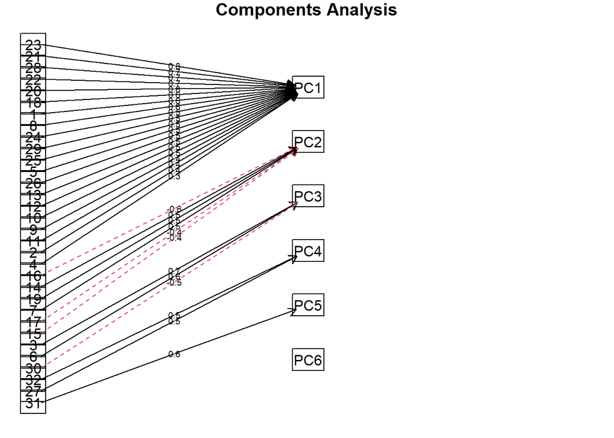

```r
fa.diagram(pcsolution1)
```

```r
pcsolution1
```

```
## Principal Components Analysis
## Call: principal(r = scaled.hp1, nfactors = 6, rotate = "none")
## Standardized loadings (pattern matrix) based upon correlation matrix
##     PC1   PC2   PC3   PC4   PC5   PC6   h2   u2 com
## 1  0.62 -0.08 -0.01 -0.35  0.16  0.21 0.59 0.41 2.0
## 2  0.36  0.28  0.07 -0.09 -0.16 -0.20 0.28 0.72 3.3
## 3  0.28 -0.03  0.67 -0.11  0.22  0.33 0.70 0.30 2.2
## 4  0.33  0.23 -0.04  0.18  0.16  0.13 0.24 0.76 3.4
## 5  0.51  0.09  0.16 -0.18  0.01 -0.06 0.33 0.67 1.6
## 6  0.42  0.07  0.64 -0.12  0.03  0.20 0.64 0.36 2.1
## 7  0.40  0.49  0.17  0.28  0.08 -0.25 0.58 0.42 3.5
## 8  0.55  0.37  0.24  0.18 -0.10  0.12 0.55 0.45 2.6
## 9  0.41  0.40 -0.01  0.25 -0.13 -0.05 0.41 0.59 2.9
## 10 0.46  0.41  0.32  0.28 -0.01 -0.19 0.60 0.40 3.9
## 11 0.40  0.38  0.18  0.30 -0.40 -0.11 0.60 0.40 4.4
## 12 0.48  0.04 -0.17 -0.01  0.04 -0.07 0.27 0.73 1.3
## 13 0.49 -0.40  0.11 -0.06  0.22 -0.06 0.46 0.54 2.5
## 14 0.23  0.51 -0.06 -0.26 -0.06  0.30 0.47 0.53 2.7
## 15 0.35 -0.40  0.29  0.13 -0.05 -0.17 0.42 0.58 3.5
## 16 0.22 -0.56  0.15  0.13 -0.04 -0.39 0.55 0.45 2.4
## 17 0.33 -0.44  0.11  0.05 -0.43 -0.04 0.50 0.50 3.0
## 18 0.63 -0.22  0.10 -0.19  0.08 -0.10 0.51 0.49 1.6
## 19 0.27  0.50 -0.23 -0.28  0.08  0.09 0.47 0.53 2.9
## 20 0.63  0.01 -0.23 -0.16  0.14 -0.34 0.62 0.38 2.1
## 21 0.71  0.06 -0.26 -0.23  0.18 -0.24 0.72 0.28 1.9
## 22 0.70  0.05 -0.16 -0.18  0.19 -0.30 0.68 0.32 1.8
## 23 0.75 -0.11 -0.04 -0.27 -0.02  0.02 0.65 0.35 1.3
## 24 0.55 -0.18  0.01 -0.23 -0.20  0.02 0.42 0.58 1.9
## 25 0.51 -0.29  0.00  0.07 -0.38  0.15 0.52 0.48 2.8
## 26 0.51 -0.24 -0.20  0.22 -0.39  0.24 0.62 0.38 3.8
## 27 0.15  0.00 -0.09  0.53 -0.04 -0.12 0.33 0.67 1.3
## 28 0.71 -0.23 -0.18  0.12 -0.01  0.33 0.72 0.28 1.9
## 29 0.51 -0.04 -0.40  0.18 -0.24  0.29 0.59 0.41 3.3
## 30 0.34  0.10 -0.46  0.13  0.06  0.09 0.36 0.64 2.3
## 31 0.35 -0.19  0.00  0.38  0.58  0.30 0.73 0.27 3.4
## 32 0.28 -0.16 -0.10  0.53  0.49  0.01 0.64 0.36 2.8
##
##                        PC1  PC2  PC3  PC4  PC5  PC6
## SS loadings           7.33 2.71 1.93 1.85 1.64 1.33
## Proportion Var        0.23 0.08 0.06 0.06 0.05 0.04
## Cumulative Var        0.23 0.31 0.37 0.43 0.48 0.52
## Proportion Explained  0.44 0.16 0.11 0.11 0.10 0.08
## Cumulative Proportion 0.44 0.60 0.71 0.82 0.92 1.00
##
## Mean item complexity =  2.6
## Test of the hypothesis that 6 components are sufficient.
##
## The root mean square of the residuals (RMSR) is  0.06
##  with the empirical chi square  516.18  with prob <  1.6e-11
##
## Fit based upon off diagonal values = 0.94
```

```r
pcsolution1$loadings
```

```
##
## Loadings:
##    PC1    PC2    PC3    PC4    PC5    PC6
## 1   0.624               -0.345  0.158  0.210
## 2   0.355  0.278               -0.164 -0.198
## 3   0.284         0.674 -0.113  0.216  0.330
## 4   0.327  0.234         0.176  0.159  0.127
## 5   0.509         0.159 -0.184
## 6   0.423         0.637 -0.116         0.200
## 7   0.398  0.492  0.167  0.280        -0.251
## 8   0.552  0.369  0.235  0.178         0.116
## 9   0.411  0.405         0.249 -0.135
## 10  0.464  0.408  0.320  0.279        -0.192
## 11  0.401  0.383  0.182  0.299 -0.397 -0.109
## 12  0.483        -0.166
```

[output cut: 25 more lines]

```r
pcsolution1$rotation
```

```
## [1] "none"
```

```r
pcsolution1$communality #variance explained
```

```
##         1         2         3         4         5         6         7         8
## 0.5853012 0.2827627 0.7037048 0.2355302 0.3293638 0.6429706 0.5759960 0.5501701
##         9        10        11        12        13        14        15        16
## 0.4147633 0.5986296 0.5987999 0.2688509 0.4632723 0.4694280 0.4216330 0.5510083
##        17        18        19        20        21        22        23        24
## 0.5033272 0.5112804 0.4650432 0.6177084 0.7222532 0.6836121 0.6542660 0.4242030
##        25        26        27        28        29        30        31        32
## 0.5196513 0.6174285 0.3272519 0.7162328 0.5927201 0.3642315 0.7264509 0.6387419
```

```r
pcsolution1$uniquenesses
```

```
##         1         2         3         4         5         6         7         8
## 0.4146988 0.7172373 0.2962952 0.7644698 0.6706362 0.3570294 0.4240040 0.4498299
##         9        10        11        12        13        14        15        16
## 0.5852367 0.4013704 0.4012001 0.7311491 0.5367277 0.5305720 0.5783670 0.4489917
##        17        18        19        20        21        22        23        24
## 0.4966728 0.4887196 0.5349568 0.3822916 0.2777468 0.3163879 0.3457340 0.5757970
##        25        26        27        28        29        30        31        32
## 0.4803487 0.3825715 0.6727481 0.2837672 0.4072799 0.6357685 0.2735491 0.3612581
```

```r
pcsolution1$values
```

```
##  [1] 7.3289851 2.7125623 1.9284264 1.8458333 1.6353971 1.3253830 1.2044231
##  [8] 1.1421697 1.0077672 0.9156160 0.9004088 0.8817464 0.8015789 0.7597415
## [15] 0.7056648 0.6834944 0.6359300 0.5966320 0.5505538 0.5426246 0.4668077
## [22] 0.4484879 0.4304351 0.3644519 0.3567825 0.3380279 0.3155461 0.2822585
## [29] 0.2572122 0.2376245 0.2246154 0.1728118
```

```r
pcsolution1$values/length(pcsolution1$values)
```

```
##  [1] 0.229030785 0.084767571 0.060263327 0.057682291 0.051106160 0.041418218
##  [7] 0.037638222 0.035692803 0.031492724 0.028613001 0.028137776 0.027554576
## [13] 0.025049342 0.023741923 0.022052025 0.021359199 0.019872812 0.018644749
## [19] 0.017204805 0.016957019 0.014587740 0.014015248 0.013451098 0.011389122
## [25] 0.011149452 0.010563372 0.009860815 0.008820579 0.008037882 0.007425766
## [31] 0.007019233 0.005400368
```

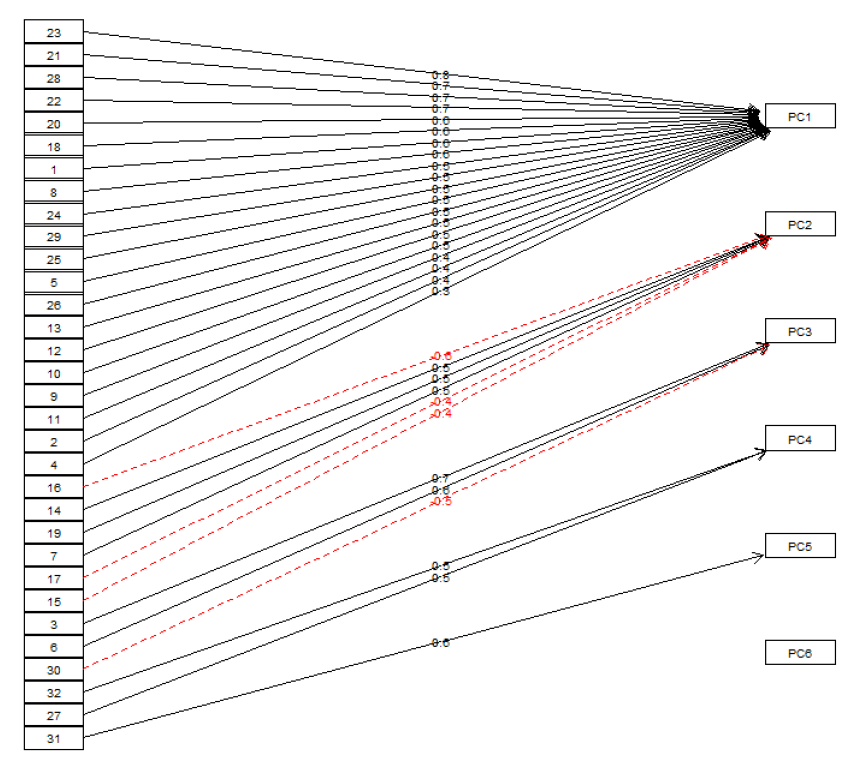

Components Analysis (No Rotation)

The components analysis of the generated PC solutions with no rotation resulted in PC6 containing no variable. Different rotation methods would be explored.

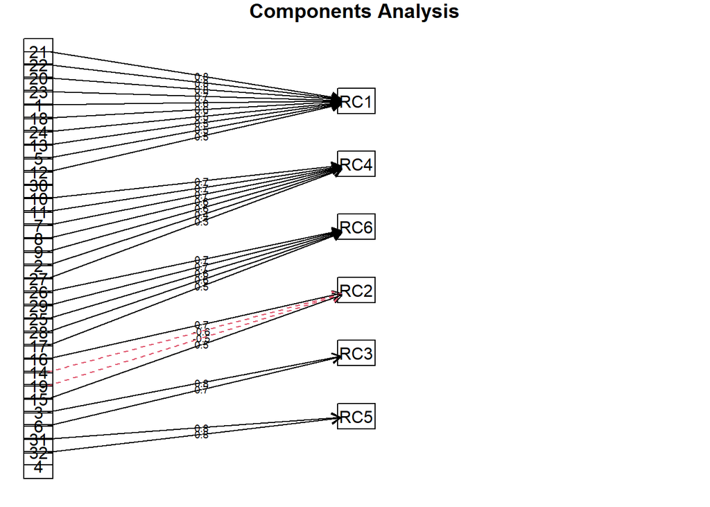

```r
pcsolution3<-principal(scaled.hp1,nfactors=6,rotate="quartimax")
fa.diagram(pcsolution3)
```

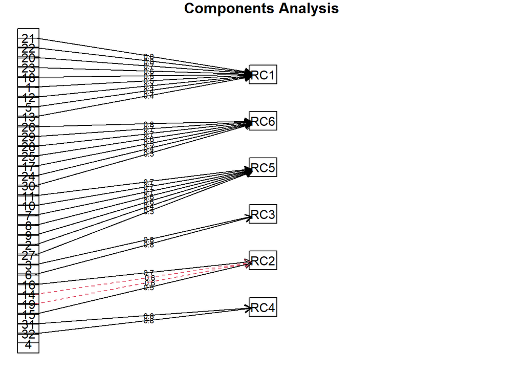

[figure not shown]

Components Analysis (EQUAMAX and QUARTIMAX)

```r
pcsolution4<-principal(scaled.hp1,nfactors=6,rotate="equamax")
fa.diagram(pcsolution4)
```

[figure not shown]

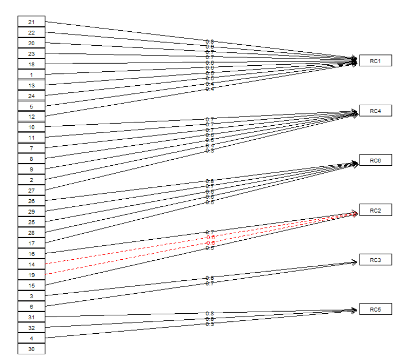

Components Analysis (VARIMAX)

```r
# VARIMAX - maximizes the variability of loadings within a factor

pcsolution1v<-principal(new_hp2,nfactors=6,rotate="varimax")
fa.diagram(pcsolution1, main = 'Components Analysis - Varimax')
```

Compared to the other rotations, VARIMAX has the most dispersed set of variables. Moreover, there is only one variable that has no factor assignment. Because of this, VARIMAX will be used.

```r
pcsolution1v$loadings
```

```
##
## Loadings:
##    RC1    RC4    RC6    RC2    RC3    RC5
## 1   0.593         0.264 -0.163  0.348  0.109
## 2   0.292  0.392                      -0.189
## 3                               0.823  0.130
## 4   0.141  0.276        -0.193         0.300
## 5   0.437  0.234                0.267
## 6   0.151  0.267                0.736
## 7   0.190  0.701 -0.138                0.156
## 8   0.169  0.592  0.221 -0.155  0.294  0.109
## 9   0.132  0.582  0.163 -0.155
## 10  0.164  0.722                0.192  0.104
## 11         0.721  0.251               -0.117
## 12  0.420  0.184  0.196                0.130
```

[output cut: 25 more lines]

```r
pcsolution1v$rotation
```

```
## [1] "varimax"
```

```r
pcsolution1v$communality
```

```
##         1         2         3         4         5         6         7         8
## 0.5853012 0.2827627 0.7037048 0.2355302 0.3293638 0.6429706 0.5759960 0.5501701
##         9        10        11        12        13        14        15        16
## 0.4147633 0.5986296 0.5987999 0.2688509 0.4632723 0.4694280 0.4216330 0.5510083
##        17        18        19        20        21        22        23        24
## 0.5033272 0.5112804 0.4650432 0.6177084 0.7222532 0.6836121 0.6542660 0.4242030
##        25        26        27        28        29        30        31        32
## 0.5196513 0.6174285 0.3272519 0.7162328 0.5927201 0.3642315 0.7264509 0.6387419
```

```r
pcsolution1v$uniquenesses
```

```
##         1         2         3         4         5         6         7         8
## 0.4146988 0.7172373 0.2962952 0.7644698 0.6706362 0.3570294 0.4240040 0.4498299
##         9        10        11        12        13        14        15        16
## 0.5852367 0.4013704 0.4012001 0.7311491 0.5367277 0.5305720 0.5783670 0.4489917
##        17        18        19        20        21        22        23        24
## 0.4966728 0.4887196 0.5349568 0.3822916 0.2777468 0.3163879 0.3457340 0.5757970
##        25        26        27        28        29        30        31        32
## 0.4803487 0.3825715 0.6727481 0.2837672 0.4072799 0.6357685 0.2735491 0.3612581
```

```r
pcsolution1v$values
```

```
##  [1] 7.3289851 2.7125623 1.9284264 1.8458333 1.6353971 1.3253830 1.2044231
##  [8] 1.1421697 1.0077672 0.9156160 0.9004088 0.8817464 0.8015789 0.7597415
## [15] 0.7056648 0.6834944 0.6359300 0.5966320 0.5505538 0.5426246 0.4668077
## [22] 0.4484879 0.4304351 0.3644519 0.3567825 0.3380279 0.3155461 0.2822585
## [29] 0.2572122 0.2376245 0.2246154 0.1728118
```

```r
pcsolution1v$values/length(pcsolution1$values)
```

```
##  [1] 0.229030785 0.084767571 0.060263327 0.057682291 0.051106160 0.041418218
##  [7] 0.037638222 0.035692803 0.031492724 0.028613001 0.028137776 0.027554576
## [13] 0.025049342 0.023741923 0.022052025 0.021359199 0.019872812 0.018644749
## [19] 0.017204805 0.016957019 0.014587740 0.014015248 0.013451098 0.011389122
## [25] 0.011149452 0.010563372 0.009860815 0.008820579 0.008037882 0.007425766
## [31] 0.007019233 0.005400368
```

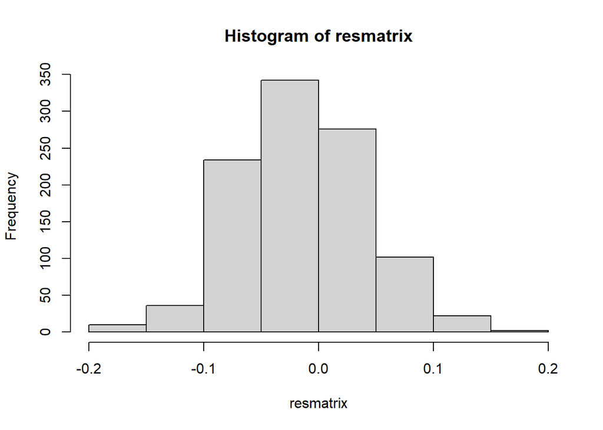

```r
L<-pcsolution1v$loadings
llT<-L%*%t(L)
uniqueness<-cor-llT
m<-matrix(0,32,32)
diag(m)<-diag(uniqueness)
resmatrix<-cor-(llT+m)

hist(resmatrix)
```

The residuals from the VARIMAX rotation are distributed along zero, indicating that the current factor model is adequate.

```r
pcsolution1v
```

```
## Principal Components Analysis
## Call: principal(r = new_hp2, nfactors = 6, rotate = "varimax")
## Standardized loadings (pattern matrix) based upon correlation matrix
##      RC1   RC4   RC6   RC2   RC3   RC5   h2   u2 com
## 1   0.59 -0.07  0.26 -0.16  0.35  0.11 0.59 0.41 2.4
## 2   0.29  0.39  0.04 -0.07  0.04 -0.19 0.28 0.72 2.5
## 3   0.05  0.08 -0.02  0.03  0.82  0.13 0.70 0.30 1.1
## 4   0.14  0.28  0.08 -0.19  0.07  0.30 0.24 0.76 3.5
## 5   0.44  0.23  0.10 -0.02  0.27 -0.05 0.33 0.67 2.4
## 6   0.15  0.27  0.07  0.04  0.74 -0.01 0.64 0.36 1.4
## 7   0.19  0.70 -0.14 -0.06  0.03  0.16 0.58 0.42 1.4
## 8   0.17  0.59  0.22 -0.16  0.29  0.11 0.55 0.45 2.3
## 9   0.13  0.58  0.16 -0.15 -0.04  0.08 0.41 0.59 1.5
## 10  0.16  0.72 -0.03  0.03  0.19  0.10 0.60 0.40 1.3
## 11  0.01  0.72  0.25  0.00  0.04 -0.12 0.60 0.40 1.3
## 12  0.42  0.18  0.20 -0.04 -0.05  0.13 0.27 0.73 2.1
## 13  0.46 -0.09  0.15  0.32  0.24  0.23 0.46 0.54 3.4
## 14  0.15  0.20  0.10 -0.60  0.16 -0.11 0.47 0.53 1.7
## 15  0.20  0.09  0.19  0.53  0.23  0.07 0.42 0.58 2.1
## 16  0.22 -0.04  0.10  0.70  0.00  0.03 0.55 0.45 1.2
## 17  0.12  0.03  0.51  0.43  0.10 -0.18 0.50 0.50 2.4
## 18  0.60  0.06  0.20  0.19  0.26  0.06 0.51 0.49 1.9
## 19  0.34  0.18 -0.02 -0.56 -0.03 -0.05 0.47 0.53 1.9
## 20  0.74  0.19  0.07  0.05 -0.12  0.08 0.62 0.38 1.2
## 21  0.81  0.18  0.11 -0.07 -0.06  0.11 0.72 0.28 1.2
## 22  0.78  0.23  0.06  0.01 -0.02  0.12 0.68 0.32 1.2
## 23  0.68  0.09  0.36 -0.01  0.23  0.01 0.65 0.35 1.8
## 24  0.46  0.05  0.39  0.09  0.18 -0.13 0.42 0.58 2.6
## 25  0.21  0.11  0.64  0.20  0.13 -0.04 0.52 0.48 1.6
## 26  0.13  0.13  0.75  0.10 -0.04  0.09 0.62 0.38 1.2
## 27 -0.10  0.33  0.15  0.21 -0.23  0.30 0.33 0.67 4.2
## 28  0.39  0.06  0.63 -0.02  0.15  0.36 0.72 0.28 2.5
## 29  0.22  0.13  0.66 -0.17 -0.15  0.20 0.59 0.41 1.8
## 30  0.26  0.10  0.28 -0.23 -0.28  0.28 0.36 0.64 5.2
## 31  0.12 -0.03  0.09  0.04  0.21  0.81 0.73 0.27 1.2
## 32  0.11  0.12  0.01  0.20 -0.06  0.75 0.64 0.36 1.3
##
##                        RC1  RC4  RC6  RC2  RC3  RC5
## SS loadings           4.63 3.03 2.90 2.13 2.11 1.97
## Proportion Var        0.14 0.09 0.09 0.07 0.07 0.06
## Cumulative Var        0.14 0.24 0.33 0.40 0.46 0.52
## Proportion Explained  0.28 0.18 0.17 0.13 0.13 0.12
## Cumulative Proportion 0.28 0.46 0.63 0.76 0.88 1.00
##
## Mean item complexity =  2
## Test of the hypothesis that 6 components are sufficient.
##
## The root mean square of the residuals (RMSR) is  0.06
##  with the empirical chi square  516.18  with prob <  1.6e-11
##
## Fit based upon off diagonal values = 0.94
```

The cumulative variance explained by the principal components is 52%. The table below summarizes the 6 factors obtained from the analysis and the corresponding variables categorized in each factor.

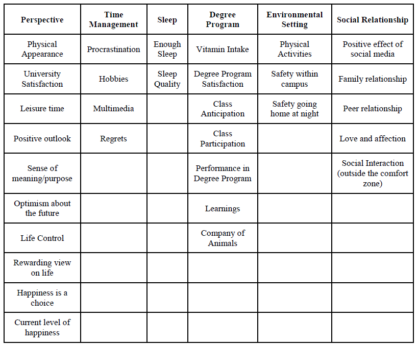

Summary of Factors

## B. Cluster Analysis

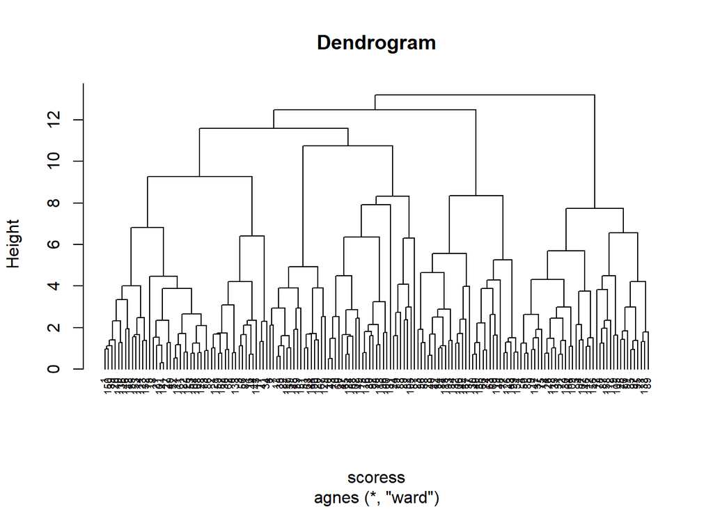

```r
#Extract the scores from VARIMAX
pcscores<-factor.scores(new_hp2,f=pcsolution1v,method="Bartlett")

scoress<-pcscores$scores

# Create clusters using the 6 factors from factor analysis
res.agnes_fa <- agnes(scoress, method = "ward")

pltree(res.agnes_fa, cex = 0.6, hang = -1,
       main = "Dendrogram")
```

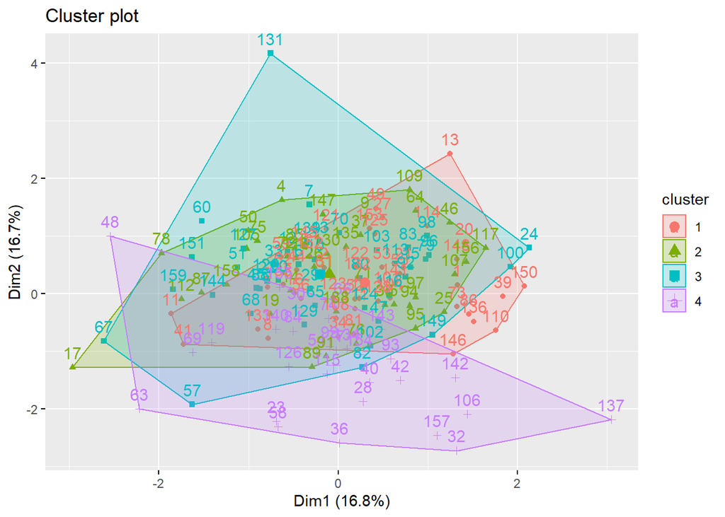

```r
grp_fa <- cutree(as.hclust(res.agnes_fa), k = 4)
fviz_cluster(list(data = scoress, cluster = grp_fa))
```

Utilizing all the 6 factors to form clusters, the cumulative variation explained by PC1 and PC2 is only 33.55%. Since this is low and the clusters overlap excessively, it was considered to remove some factors.

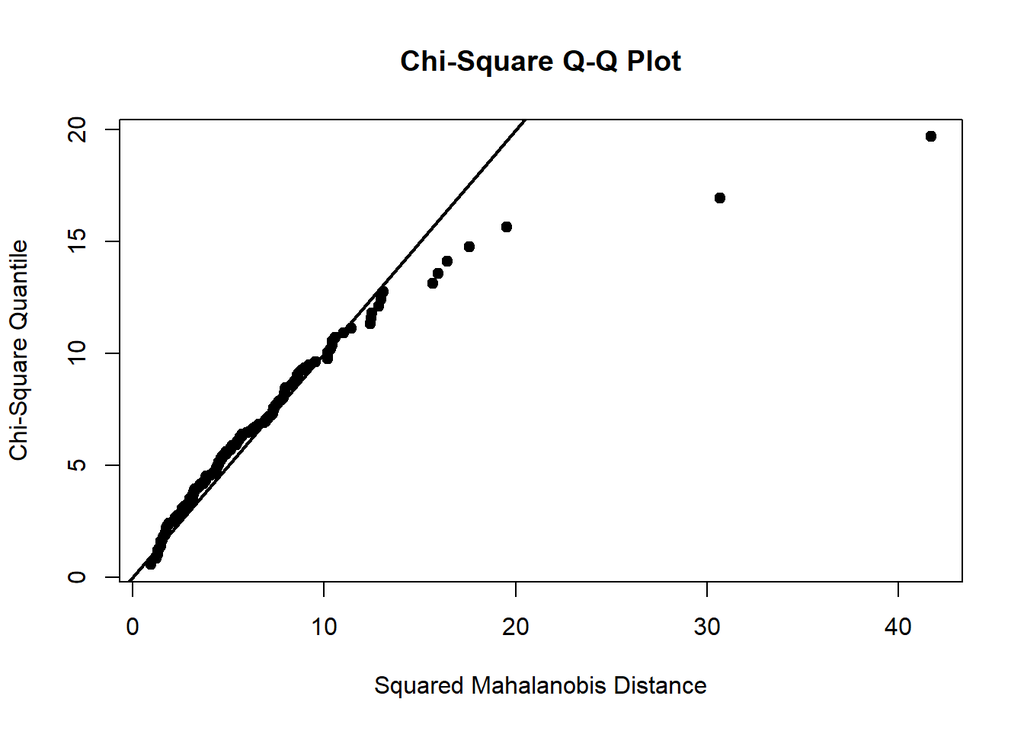

```
## $multivariateNormality
##            Test       HZ      p value MVN
## 1 Henze-Zirkler 1.130275 2.392726e-05  NO
##
## $univariateNormality
##               Test  Variable Statistic   p value Normality
## 1 Anderson-Darling    RC1       0.4178    0.3257    YES
## 2 Anderson-Darling    RC4       0.3609    0.4424    YES
## 3 Anderson-Darling    RC6       0.6891    0.0706    YES
## 4 Anderson-Darling    RC2       0.5213    0.1822    YES
## 5 Anderson-Darling    RC3       0.9887    0.0128    NO
## 6 Anderson-Darling    RC5       1.2690    0.0026    NO
##
## $Descriptives
##       n          Mean  Std.Dev       Median       Min      Max       25th
## RC1 159 -1.361431e-16 1.006107  0.022508334 -3.325116 2.394211 -0.6477771
## RC4 159  4.558491e-17 1.004085  0.003587867 -2.618578 2.891897 -0.6486343
## RC6 159  4.474211e-17 1.004408 -0.100346198 -3.061909 2.693130 -0.6114148
## RC2 159 -1.879381e-16 1.004047 -0.082708023 -5.061796 1.990922 -0.6555958
## RC3 159 -4.681571e-17 1.008429 -0.117191375 -2.234044 2.636265 -0.6836079
## RC5 159  1.593095e-17 1.015208  0.216338192 -3.110614 3.044366 -0.6829234
##          75th        Skew    Kurtosis
## RC1 0.6178239 -0.10104996  0.04435192
## RC4 0.6262030  0.04268047 -0.34623433
## RC6 0.6952380 -0.06060268  0.25546508
## RC2 0.7274664 -0.71101252  2.71681371
## RC3 0.7172917  0.30655986 -0.48175851
## RC5 0.7372391 -0.28023719  0.30390426
```

```r
# Multivariate Normality test
mvn(scoress,subset=NULL,multivariatePlot = "qq")
```

```r
hz_test = mvn(scoress, mvnTest = "hz")
royston_test = mvn(scoress, mvnTest = "royston")
```

```r
kable(hz_test$univariateNormality)
```

| Test | Variable | Statistic | p value | Normality |
| --- | --- | --- | --- | --- |
| Anderson-Darling | RC1 | 0.4178 | 0.3257 | YES |
| Anderson-Darling | RC4 | 0.3609 | 0.4424 | YES |
| Anderson-Darling | RC6 | 0.6891 | 0.0706 | YES |
| Anderson-Darling | RC2 | 0.5213 | 0.1822 | YES |
| Anderson-Darling | RC3 | 0.9887 | 0.0128 | NO |
| Anderson-Darling | RC5 | 1.2690 | 0.0026 | NO |

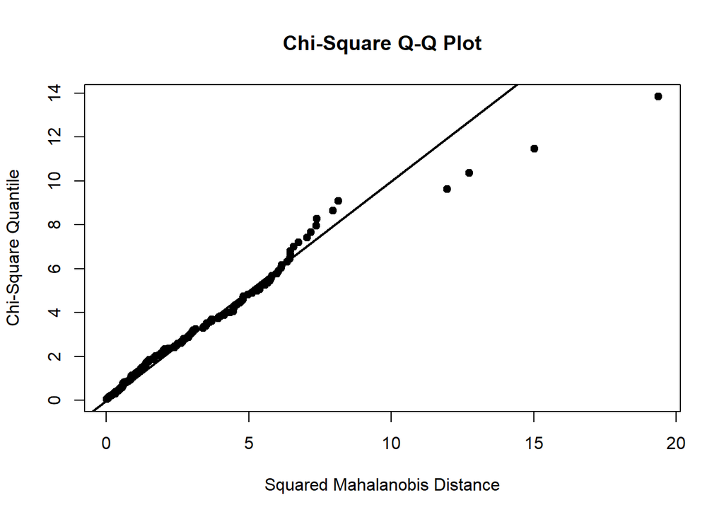

```
## $multivariateNormality
##            Test       HZ    p value MVN
## 1 Henze-Zirkler 1.007624 0.05420563 YES
##
## $univariateNormality
##               Test  Variable Statistic   p value Normality
## 1 Anderson-Darling    RC1       0.4178    0.3257    YES
## 2 Anderson-Darling    RC4       0.3609    0.4424    YES
## 3 Anderson-Darling    RC6       0.6891    0.0706    YES
##
## $Descriptives
##       n          Mean  Std.Dev       Median       Min      Max       25th
## RC1 159 -1.361431e-16 1.006107  0.022508334 -3.325116 2.394211 -0.6477771
## RC4 159  4.558491e-17 1.004085  0.003587867 -2.618578 2.891897 -0.6486343
## RC6 159  4.474211e-17 1.004408 -0.100346198 -3.061909 2.693130 -0.6114148
##          75th        Skew    Kurtosis
## RC1 0.6178239 -0.10104996  0.04435192
## RC4 0.6262030  0.04268047 -0.34623433
## RC6 0.6952380 -0.06060268  0.25546508
```

```r
# Extract the factors that are univariate normal to create clusters.
pc_fin <- scoress[, -(4:6)]
mvn(pc_fin,subset=NULL,multivariatePlot = "qq")
```

Upon the removal of the non-normal factors, the distribution of the data is closer to multivariate normal.

### B.1. Hierarchical Clustering

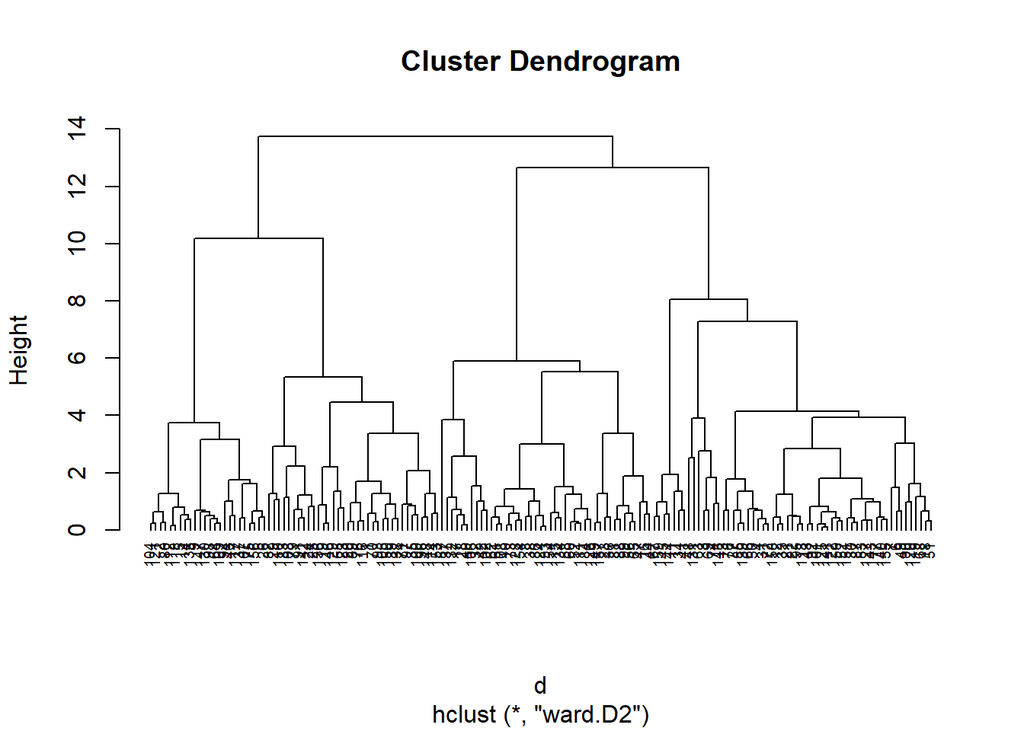

```r
d<-dist(pc_fin, method="euclidean")
res.hc<-hclust(d,method="ward.D2")
plot(res.hc,cex=0.6,hang=-1)
```

#### B.1.a. Agglomerative

```r
res.agnes <- agnes(pc_fin, method = "ward")
# summary(res.agnes)
res.agnes$ac
```

```
## [1] 0.9588164
```

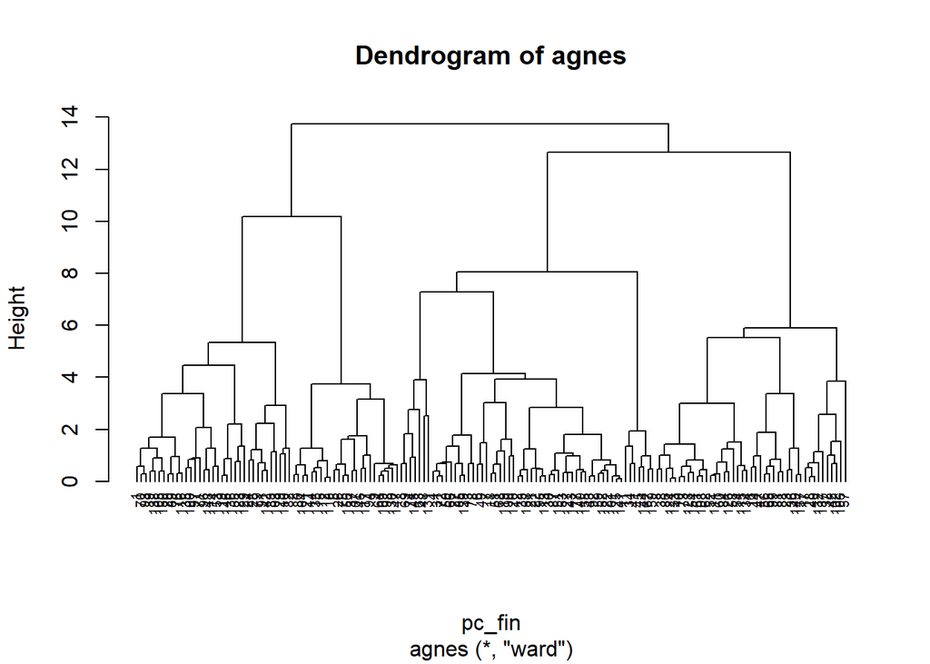

```r
pltree(res.agnes, cex = 0.6, hang = -1,
       main = "Dendrogram of agnes")
```

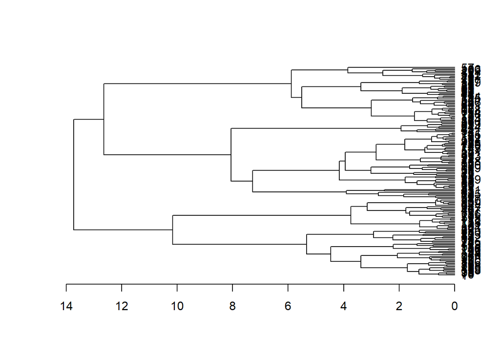

```r
plot(as.dendrogram(res.agnes), cex = 0.6,
     horiz = TRUE)
```

```r
grp <- cutree(as.hclust(res.agnes), k = 3)
```

```r
table(grp)
```

```
## grp
##  1  2  3
## 59 57 43
```

The obtained coefficient from the agglomerative method is 0.9588. Since this is close to 1, we can conclude that the clustering using this method is already sufficient. Based on the dendogram, we can group the observations into three clusters. The first cluster contains 59 observations, the second cluster contains 57 observations, and the third cluster contains 43 observations. These clusters are plotted below.

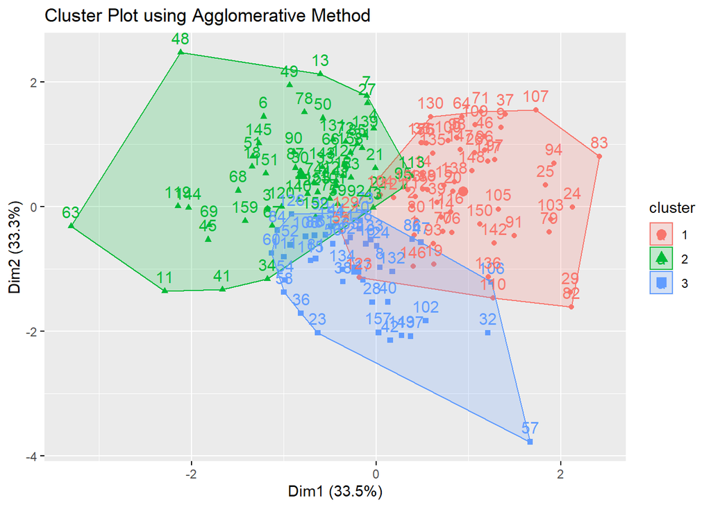

```r
fviz_cluster(list(data=pc_fin, cluster=grp), main = 'Cluster Plot using Agglomerative Method')
```

From the cluster plot, PC1 and PC2 explain 66.8% of the total variability in the data. Compared to the previous cluster plot where all factors was utilized, the cluster plot using only 3 factors reduced the problem of excessive overlapping.

#### B.1.b. Divisive

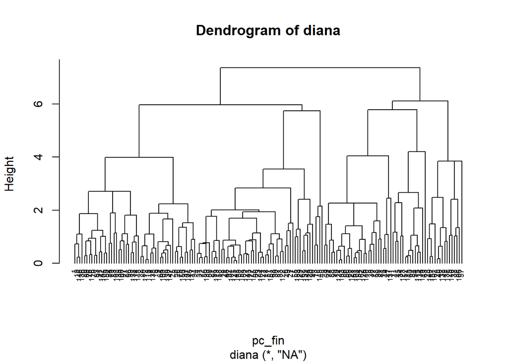

```r
res.diana <- diana(pc_fin)
pltree(res.diana, cex = 0.6, hang = -1,
       main = "Dendrogram of diana")
```

```r
res.diana$dc
```

```
## [1] 0.9129347
```

```r
grp_div <- cutree(as.hclust(res.diana), k = 3)
# Number of members in each cluster
table(grp_div)
```

```
## grp_div
##   1   2   3
## 102  42  15
```

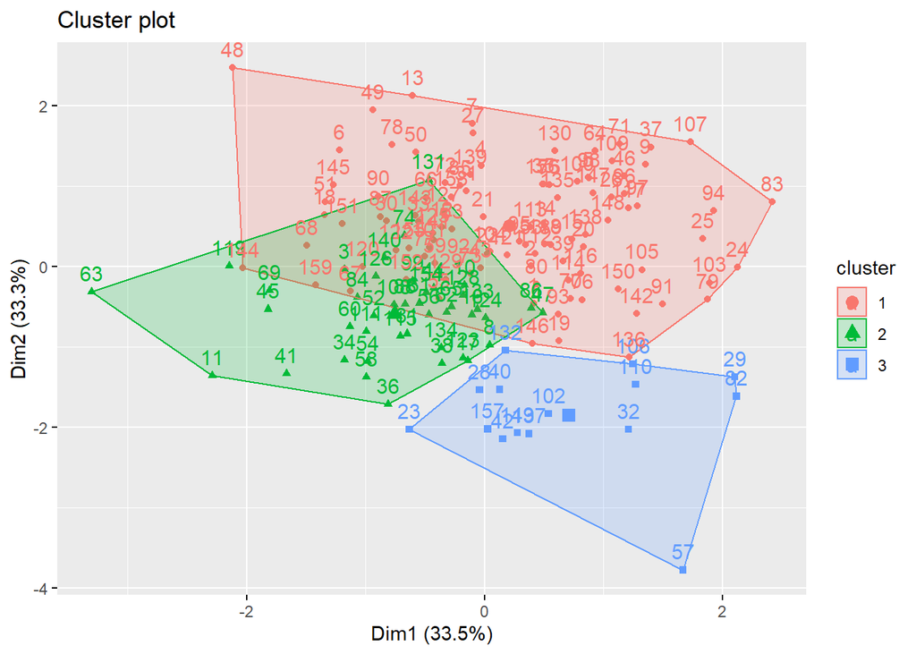

```r
fviz_cluster(list(data = pc_fin, cluster = grp_div))
```

The divisive coefficient is 91.29%. This is less than the obtained agglomerative coefficient of 95.88%, indicating that the agglomerative method produced better clustering.

### B.2. Non-hierarchical Clustering

#### B.2.a. K-means clustering

```r
df<-pc_fin
df <- na.omit(df)
df <- scale(df)
head(df)
```

```
##             RC1          RC4         RC6
## [1,]  0.2372729  0.647263867  0.94567040
## [2,] -0.6052084 -0.221401560 -0.07735138
## [3,]  0.2975854 -0.003204691 -1.36302807
## [4,]  0.2222225 -1.264993806 -0.09990577
## [5,] -1.1033870 -1.558145714 -0.16875069
## [6,]  1.7617537 -0.973842322 -0.24187815
```

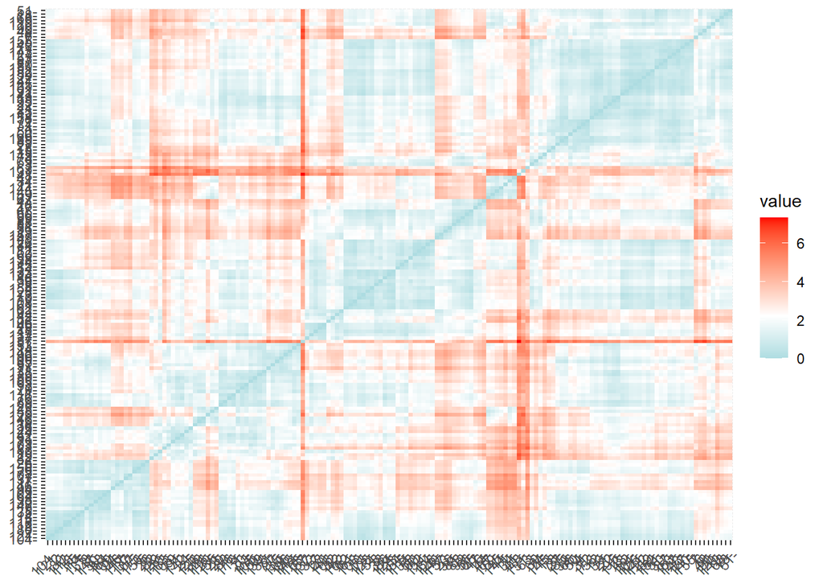

```r
distance <- get_dist(df)
fviz_dist(distance, gradient = list(low = "#00AFBB", mid = "white", high = "red" )) #"#FC4E07"
```

```r
func1 <- function(k) {
  kmeans(df, k, nstart = 10 )$betweenss/(kmeans(df, k, nstart = 10 )$tot.withinss+kmeans(df, k, nstart = 10 )$betweenss)
}
```

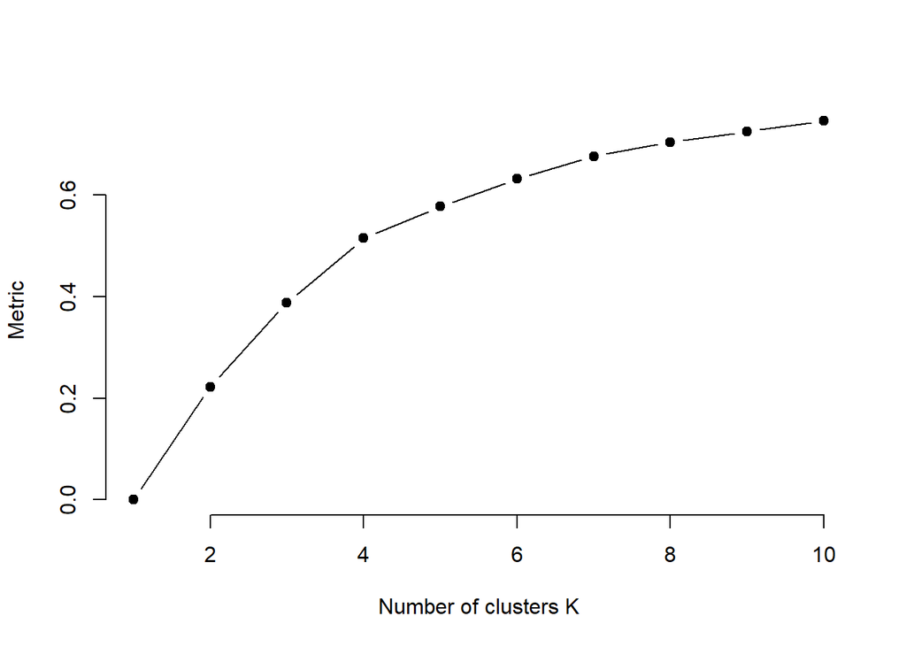

```r
k.values <- 1:10
values <- map_dbl(k.values, func1)
plot(k.values, values,
     type="b", pch = 19, frame = FALSE,
     xlab="Number of clusters K",
     ylab="Metric")
```

### B.3. Optimal Number of Clusters

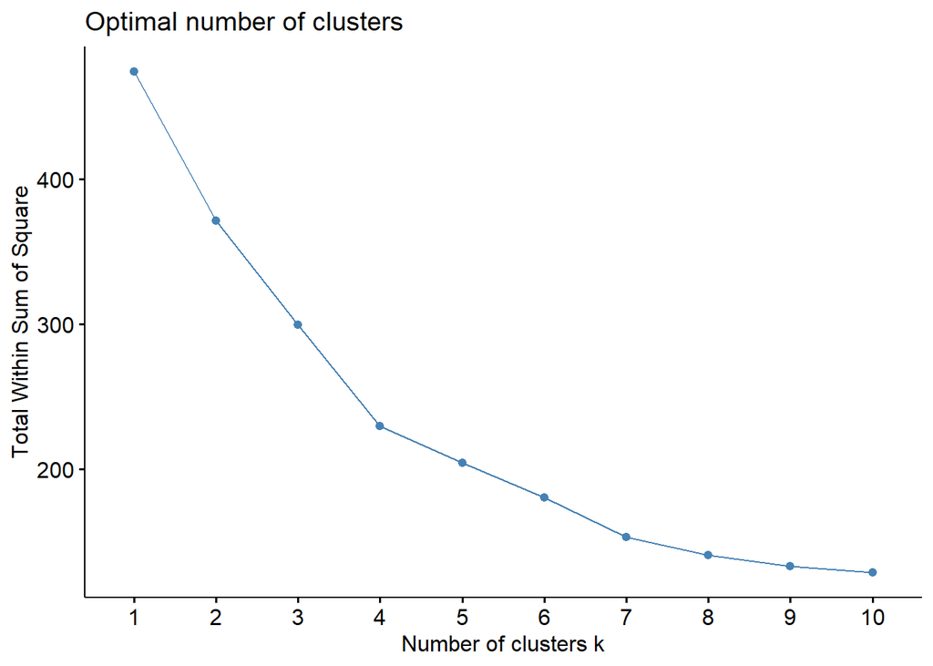

```r
fviz_nbclust(df, kmeans, method = "wss")
```

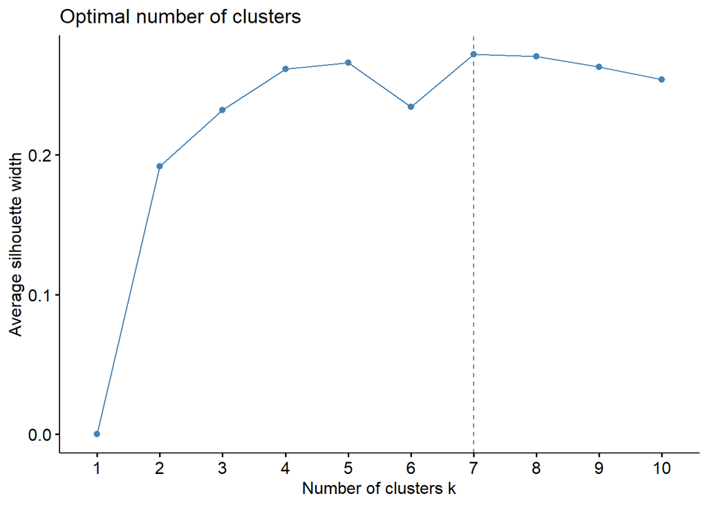

```r
fviz_nbclust(df, kmeans, method = "silhouette")
```

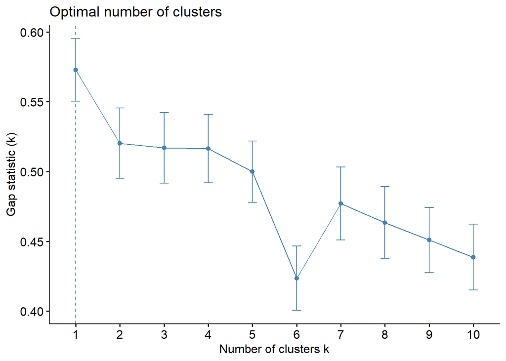

```r
fviz_nbclust(df, kmeans, method = "gap_stat")
```

### B.4. Final Clusters and Insights

```r
final <- kmeans(df, 3, nstart = 25)
print(final)
```

```
## K-means clustering with 3 clusters of sizes 71, 35, 53
##
## Cluster means:
##          RC1         RC4        RC6
## 1  0.7932786 -0.04598114 -0.3660569
## 2 -0.9731223  0.77628948 -0.6077800
## 3 -0.4200660 -0.45104662  0.8917423
##
## Clustering vector:
##   [1] 3 3 1 1 3 1 1 2 3 1 1 1 1 3 3 2 2 1 3 3 1 1 2 3 3 3 1 2 3 1 1 2 1 1 3 2 3
##  [38] 2 3 2 1 2 1 2 1 3 2 1 1 1 1 1 1 1 1 2 2 2 1 1 1 2 1 3 2 1 1 1 1 3 3 1 1 1
##  [75] 3 3 1 1 3 2 2 2 3 1 1 2 1 2 3 1 3 1 3 3 3 3 3 3 2 3 1 2 3 1 3 2 3 1 3 2 1
## [112] 2 3 3 1 3 3 3 1 1 3 1 1 2 1 1 1 2 1 3 2 2 2 1 3 3 2 3 1 1 1 3 1 1 1 3 3 3
## [149] 2 3 1 1 3 1 1 3 2 1 1
##
## Within cluster sum of squares by cluster:
## [1] 130.88235  68.00464  91.32434
##  (between_SS / total_SS =  38.8 %)
##
## Available components:
##
## [1] "cluster"      "centers"      "totss"        "withinss"     "tot.withinss"
## [6] "betweenss"    "size"         "iter"         "ifault"
```

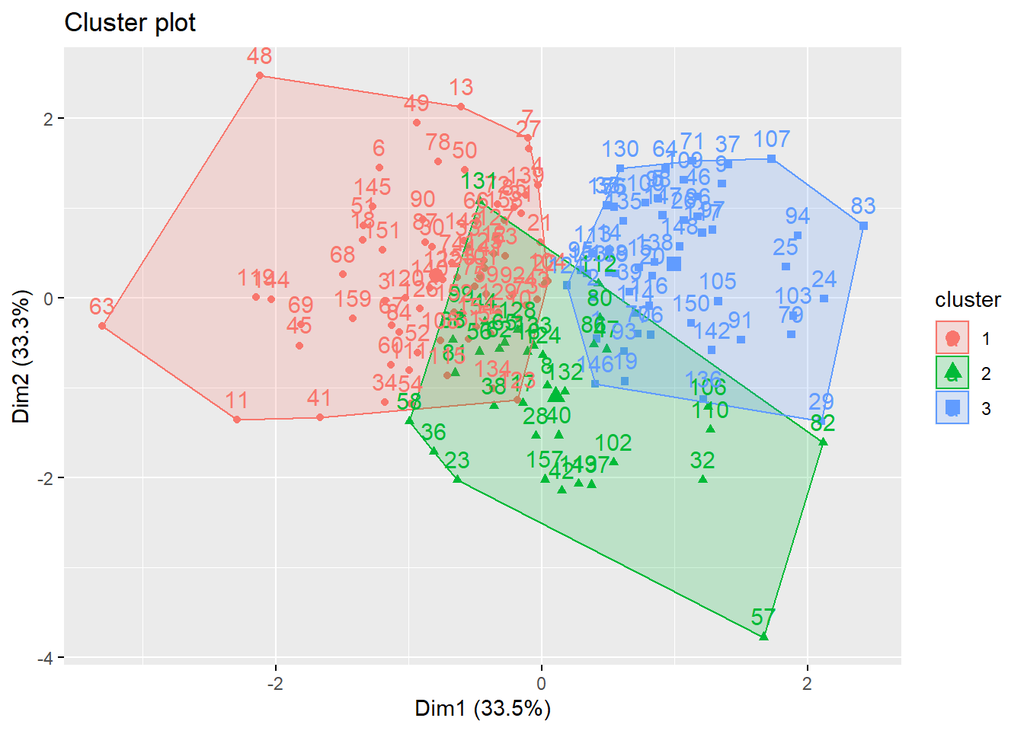

```r
fviz_cluster(final, data = df)
```